# training & validation

Kaylee Ye

2024-04-07

```r
mydata <- read.csv("../data/dayDataForReport4.csv")
library(car)
library(caret)
```

```r
library(ggplot2)
library(MLmetrics)
library(dplyr)
library(GGally)
library(olsrr)
library(MASS)
```

#We create new variables for ‘Season’,“Workingday” and ‘Weather’ based on the ‘Season’, “Workingday” and ‘Weather’ columns.

```r
#season
mydata$season <- cut(mydata$season,
                     breaks = c(0.5, 1.5, 2.5, 3.5, 4.5),
                     labels = c("Winter", "Spring", "Summer", "Fall"))
mydata$season <- factor(mydata$season, levels = c("Winter", "Spring", "Summer", "Fall"))

#workingday
mydata$workingday <- ifelse(mydata$workingday == 0, "Not_Workingday", "Workingday")
mydata$workingday <- factor(mydata$workingday, levels = c("Not_Workingday", "Workingday"))

#weather
mydata$weathersit <- cut(mydata$weathersit,
                         breaks = c(0.5, 1.5, 2.5, 3.5, 4.5),
                         labels = c("Weather_1", "Weather_2", "Weather_3", "Weather_4"))
mydata$weathersit <- factor(mydata$weathersit, levels = c("Weather_1", "Weather_2", "Weather_3", "Weather_4"))
```

# Data Splitting (Training & Validation): We split the data into training (year = 2011) and validation sets (year = 2012)

```r
# Assuming 'yr' is the column in 'mydata' indicating the year
# Initialize 'Type' column to NA
mydata$Type <- NA

mydata$Type[mydata$yr == 0] <- "Training"

# Assign 'Validation' to rows where 'yr' is not 0
mydata$Type[mydata$yr != 0] <- "Validation"

# Identify indices for training (year 2011)
#index <- mydata$yr == 0

# Assign 'Training' to rows where 'yr' is 2011, 'Validation' otherwise
#mydata$Type[index] <- "Training"
#mydata$Type[-index] <- "Validation"  # '!' is used to negate the index, for years not equal to 2011

# Now, you can split the data based on the 'Type' column
training_set <- mydata[mydata$Type == "Training", ]
validation_set <- mydata[mydata$Type == "Validation", ]
```

```r
table(mydata$season, mydata$Type)
```

```
##
##          Training Validation
##   Winter       90         91
##   Spring       92         92
##   Summer       94         94
##   Fall         89         89
```

```r
table(mydata$workingday, mydata$Type)
```

```
##
##                  Training Validation
##   Not_Workingday      115        116
##   Workingday          250        250
```

```r
table(mydata$weathersit, mydata$Type)
```

```
##
##             Training Validation
##   Weather_1      226        237
##   Weather_2      124        123
##   Weather_3       15          6
##   Weather_4        0          0
```

```r
#table(mydata$cnt, mydata$Type)
```

## Comparison Training & Validation Data Sets

# Comparison Training & Validation Data Sets

### Y values for all three models: cnt, registered and sqrt(casual) users

### Boxplots

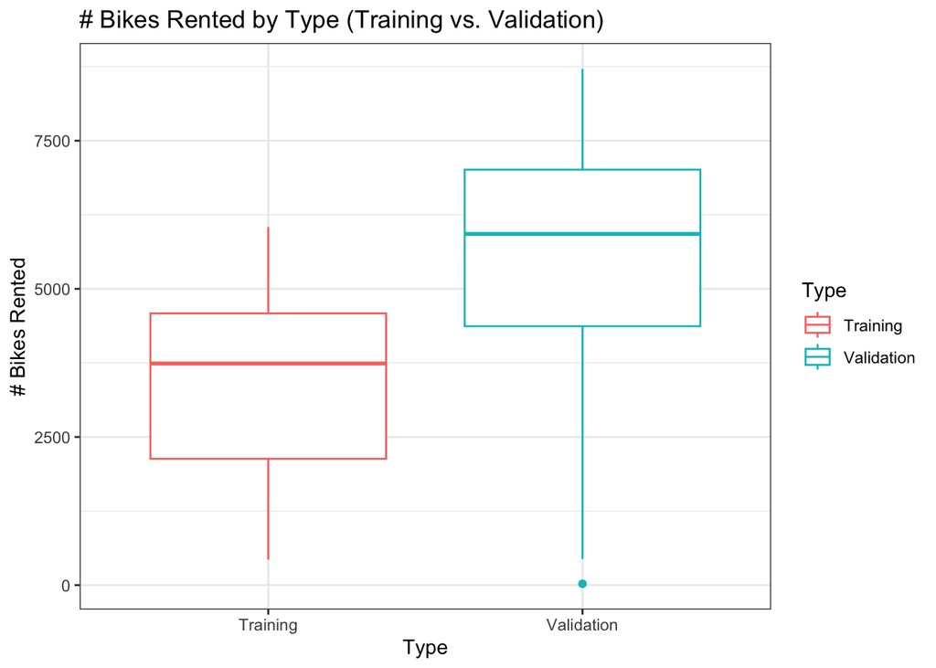

```r
#cnt
ggplot(mydata, aes(x = Type, y = cnt, color = Type)) +
  geom_boxplot(position = position_dodge(width = 0.8)) +
  labs(x = "Type", y = "# Bikes Rented") +
  scale_fill_manual(name = "Dataset Type", values = c("Training" = "blue", "Validation" = "red")) +
  ggtitle("# Bikes Rented by Type (Training vs. Validation)") +
  theme_bw()
```

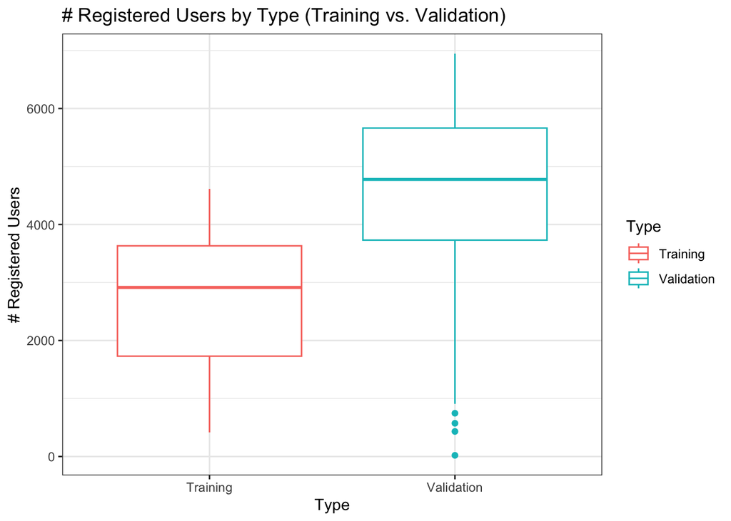

```r
#registered
ggplot(mydata, aes(x = Type, y = registered, color = Type)) +
  geom_boxplot(position = position_dodge(width = 0.8)) +
  labs(x = "Type", y = "# Registered Users") +
  scale_fill_manual(name = "Dataset Type", values = c("Training" = "blue", "Validation" = "red")) +
  ggtitle("# Registered Users by Type (Training vs. Validation)") +
  theme_bw()
```

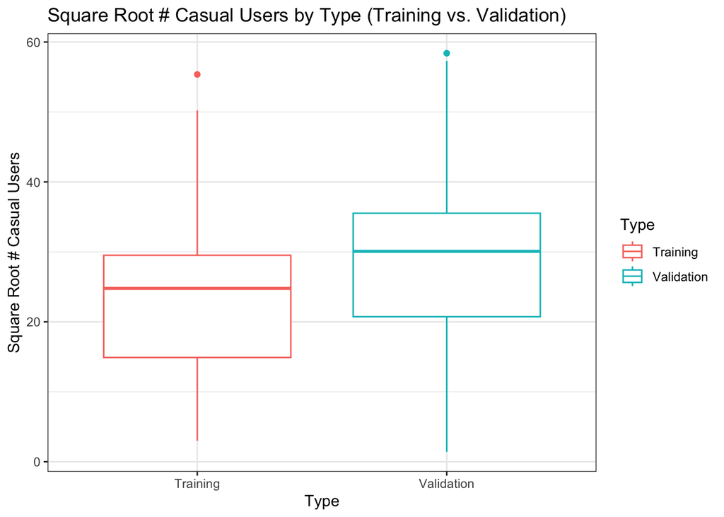

```r
#sqrt(casual)
ggplot(mydata, aes(x = Type, y = sqrt(casual), color = Type)) +
  geom_boxplot(position = position_dodge(width = 0.8)) +
  labs(x = "Type", y = "Square Root # Casual Users") +
  scale_fill_manual(name = "Dataset Type", values = c("Training" = "blue", "Validation" = "red")) +
  ggtitle("Square Root # Casual Users by Type (Training vs. Validation)") +
  theme_bw()
```

#### Histograms and Summary

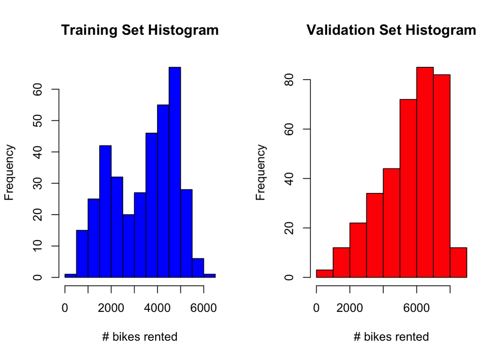

```r
# Open a plotting window with 1 row and 2 columns
par(mfrow = c(1, 2))
hist(training_set$cnt, main = "Training Set Histogram", xlab = "# bikes rented", col = "blue")
hist(validation_set$cnt, main = "Validation Set Histogram", xlab = "# bikes rented", col = "red")
```

```r
par(mfrow = c(1, 1))
```

The Histogram shows that the distribution of cnt in training dataset shows a bimodal shape which has two peaks, while the validation shows left skewed with only one peak.

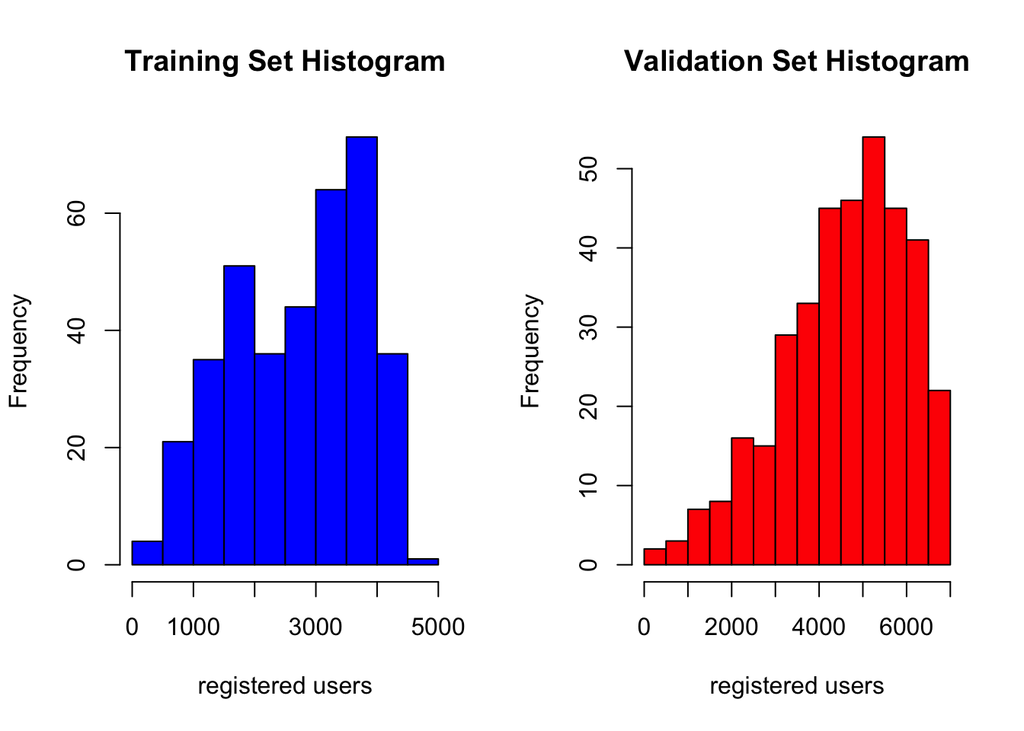

```r
#for registered
par(mfrow = c(1, 2))
hist(training_set$registered, main = "Training Set Histogram", xlab = "registered users", col = "blue")
hist(validation_set$registered, main = "Validation Set Histogram", xlab = "registered users", col = "red")
```

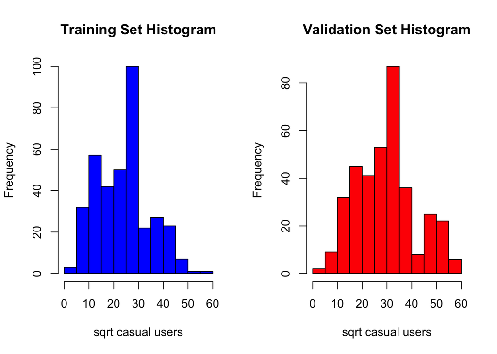

```r
par(mfrow = c(1, 1))

#for casual
par(mfrow = c(1, 2))
training_set$sqrt_casual <- sqrt(training_set$casual)
validation_set$sqrt_casual <- sqrt(validation_set$casual)
hist(training_set$sqrt_casual, main = "Training Set Histogram", xlab = "sqrt casual users", col = "blue")
hist(validation_set$sqrt_casual, main = "Validation Set Histogram", xlab = "sqrt casual users", col = "red")
```

```r
par(mfrow = c(1, 1))
```

## X values: categorical: [yr(?), weather, season, workingday] continuous: [temp, wind, hum]

#### For categorical

```r
#model1 <- lm(registered~as.factor(workingday) + as.factor(yr) + as.factor(weather))
#model2 <- lm(sqrt(casual)~as.factor(season) + as.factor(yr) + as.factor(weather) + as.factor(workingday))
#model3 <- lm(cnt ~  temp + wind + hum + as.factor(yr) + as.factor(workingday))

# Assuming 'training_set' and 'validation_set' are your datasets

# WorkingDay
training_counts_workingday <- table(training_set$workingday)
validation_counts_workingday <- table(validation_set$workingday)

training_props_workingday <- prop.table(training_counts_workingday)
validation_props_workingday <- prop.table(validation_counts_workingday)

# Season
training_counts_season <- table(training_set$season)
validation_counts_season <- table(validation_set$season)

training_props_season <- prop.table(training_counts_season)
validation_props_season <- prop.table(validation_counts_season)

# Year
training_counts_yr <- table(training_set$yr)
validation_counts_yr <- table(validation_set$yr)

training_props_yr <- prop.table(training_counts_yr)
validation_props_yr <- prop.table(validation_counts_yr)

# Holiday
training_counts_holiday <- table(training_set$holiday)
validation_counts_holiday <- table(validation_set$holiday)

training_props_holiday <- prop.table(training_counts_holiday)
validation_props_holiday <- prop.table(validation_counts_holiday)

# Weathersit
training_counts_weathersit <- table(training_set$weathersit)
validation_counts_weathersit <- table(validation_set$weathersit)

training_props_weathersit <- prop.table(training_counts_weathersit)
validation_props_weathersit <- prop.table(validation_counts_weathersit)
```

```r
# Printing out the tables
# For a better layout, you might want to print these one by one or use a custom layout with a package like gridExtra
#working day
cat("Training Set - Working Day Count and Proportion")
```

```
## Training Set - Working Day Count and Proportion
```

```r
print(training_counts_workingday)
```

```
##
## Not_Workingday     Workingday
##            115            250
```

```r
print(training_props_workingday)
```

```
##
## Not_Workingday     Workingday
##      0.3150685      0.6849315
```

```r
cat("\nValidation Set - Working Day Count and Proportion")
```

```
##
## Validation Set - Working Day Count and Proportion
```

```r
print(validation_counts_workingday)
```

```
##
## Not_Workingday     Workingday
##            116            250
```

```r
print(validation_props_workingday)
```

```
##
## Not_Workingday     Workingday
##      0.3169399      0.6830601
```

```r
cat("\n")
```

```r
#season
cat("Training Set - Season Count and Proportion")
```

```
## Training Set - Season Count and Proportion
```

```r
print(training_counts_season)
```

```
##
## Winter Spring Summer   Fall
##     90     92     94     89
```

```r
print(training_props_season)
```

```
##
##    Winter    Spring    Summer      Fall
## 0.2465753 0.2520548 0.2575342 0.2438356
```

```r
cat("\nValidation Set - Season Count and Proportion")
```

```
##
## Validation Set - Season Count and Proportion
```

```r
print(validation_counts_season)
```

```
##
## Winter Spring Summer   Fall
##     91     92     94     89
```

```r
print(validation_props_season)
```

```
##
##    Winter    Spring    Summer      Fall
## 0.2486339 0.2513661 0.2568306 0.2431694
```

```r
cat("\n")
```

```r
#year
cat("Training Set - Year Count and Proportion")
```

```
## Training Set - Year Count and Proportion
```

```r
print(training_counts_yr)
```

```
##
##   0
## 365
```

```r
print(training_props_yr)
```

```
##
## 0
## 1
```

```r
cat("\nValidation Set - Year Count and Proportion")
```

```
##
## Validation Set - Year Count and Proportion
```

```r
print(validation_counts_yr)
```

```
##
##   1
## 366
```

```r
print(validation_props_yr)
```

```
##
## 1
## 1
```

```r
cat("\n")
```

```r
#holiday
cat("Training Set - Holiday Count and Proportion")
```

```
## Training Set - Holiday Count and Proportion
```

```r
print(training_counts_holiday)
```

```
##
##   0   1
## 355  10
```

```r
print(training_props_holiday)
```

```
##
##          0          1
## 0.97260274 0.02739726
```

```r
cat("\nValidation Set - Holiday Count and Proportion")
```

```
##
## Validation Set - Holiday Count and Proportion
```

```r
print(validation_counts_holiday)
```

```
##
##   0   1
## 355  11
```

```r
print(validation_props_holiday)
```

```
##
##          0          1
## 0.96994536 0.03005464
```

```r
cat("\n")
```

```r
#weathersit
cat("Training Set - Weathersit Count and Proportion")
```

```
## Training Set - Weathersit Count and Proportion
```

```r
print(training_counts_weathersit)
```

```
##
## Weather_1 Weather_2 Weather_3 Weather_4
##       226       124        15         0
```

```r
print(training_props_weathersit)
```

```
##
##  Weather_1  Weather_2  Weather_3  Weather_4
## 0.61917808 0.33972603 0.04109589 0.00000000
```

```r
cat("\nValidation Set - Weathersit Count and Proportion")
```

```
##
## Validation Set - Weathersit Count and Proportion
```

```r
print(validation_counts_weathersit)
```

```
##
## Weather_1 Weather_2 Weather_3 Weather_4
##       237       123         6         0
```

```r
print(validation_props_weathersit)
```

```
##
##  Weather_1  Weather_2  Weather_3  Weather_4
## 0.64754098 0.33606557 0.01639344 0.00000000
```

The categorical variables in the two data sets have similar counts and proportions.

#### For continuous

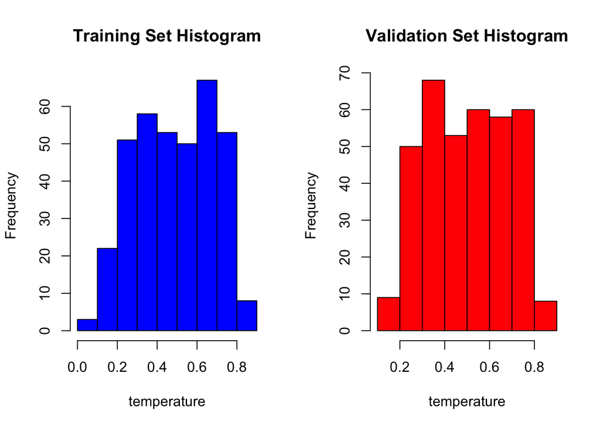

```r
#For temp
par(mfrow = c(1, 2))
hist(training_set$temp, main = "Training Set Histogram", xlab = "temperature", col = "blue")
hist(validation_set$temp, main = "Validation Set Histogram", xlab = "temperature", col = "red")
```

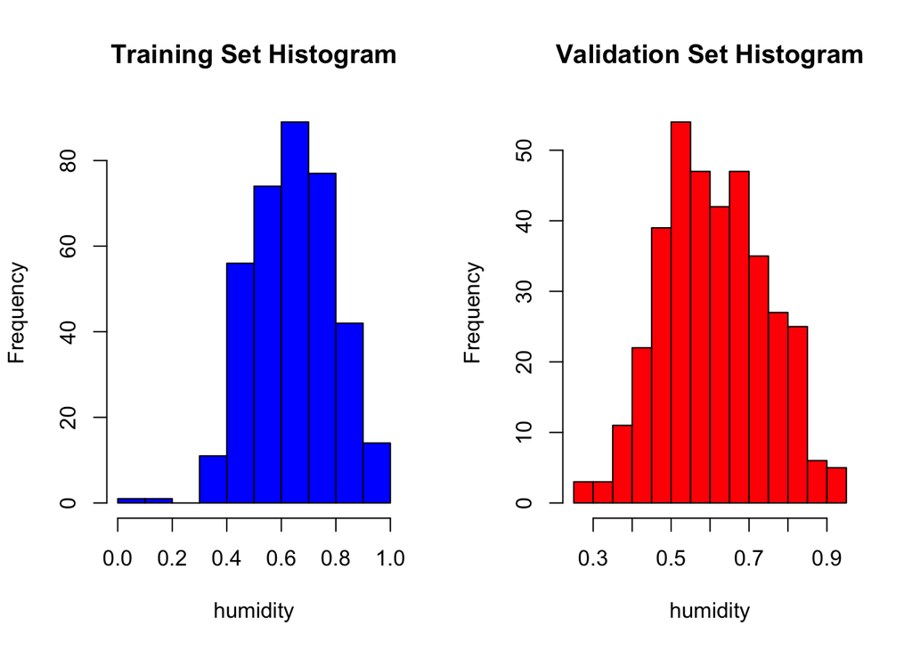

```r
par(mfrow = c(1, 1))

#For hum
par(mfrow = c(1, 2))
hist(training_set$hum, main = "Training Set Histogram", xlab = "humidity", col = "blue")
hist(validation_set$hum, main = "Validation Set Histogram", xlab = "humidity", col = "red")
```

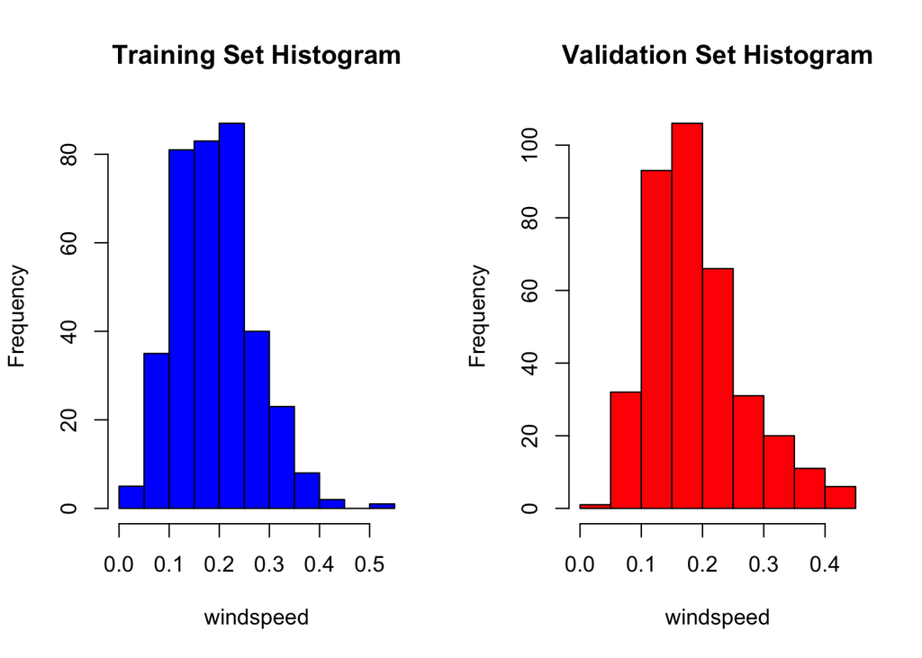

```r
par(mfrow = c(1, 1))

#For windspeed
par(mfrow = c(1, 2))
hist(training_set$windspeed, main = "Training Set Histogram", xlab = "windspeed", col = "blue")
hist(validation_set$windspeed, main = "Validation Set Histogram", xlab = "windspeed", col = "red")
```

```r
par(mfrow = c(1, 1))
```

# Model Fitting & obtain outputs of the model

```r
#training_data <- subset(mydata, Type == "Training")
# Fit the three model we derived in report 3:
#model1
model1 <- lm(registered~as.factor(workingday) + as.factor(weathersit),data = training_set)
summary(model1) #adjusted r^2 = 0.1927
```

```
##
## Call:
## lm(formula = registered ~ as.factor(workingday) + as.factor(weathersit),
##     data = training_set)
##
## Residuals:
##     Min      1Q  Median      3Q     Max
## -2770.6  -940.7   358.4   732.7  1680.3
##
## Coefficients:
##                                 Estimate Std. Error t value Pr(>|t|)
## (Intercept)                      2396.97      94.59  25.339  < 2e-16 ***
## as.factor(workingday)Workingday   789.66     107.99   7.312 1.71e-12 ***
## as.factor(weathersit)Weather_2   -430.29     106.76  -4.031 6.79e-05 ***
## as.factor(weathersit)Weather_3  -1540.07     255.03  -6.039 3.86e-09 ***
## ---
## Signif. codes:  0 '***' 0.001 '**' 0.01 '*' 0.05 '.' 0.1 ' ' 1
##
## Residual standard error: 952.5 on 361 degrees of freedom
## Multiple R-squared:  0.1994, Adjusted R-squared:  0.1927
## F-statistic: 29.97 on 3 and 361 DF,  p-value: < 2.2e-16
```

```r
#model2
model2 <- lm(sqrt(casual)~as.factor(season) + as.factor(weathersit) + as.factor(workingday),data = training_set)
summary(model2) #adjusted r^2 = 0.6873
```

```
##
## Call:
## lm(formula = sqrt(casual) ~ as.factor(season) + as.factor(weathersit) +
##     as.factor(workingday), data = training_set)
##
## Residuals:
##      Min       1Q   Median       3Q      Max
## -20.9963  -3.5717   0.0082   3.6853  19.3328
##
## Coefficients:
##                                 Estimate Std. Error t value Pr(>|t|)
## (Intercept)                      22.5236     0.7917  28.449  < 2e-16 ***
## as.factor(season)Spring          14.3744     0.8760  16.409  < 2e-16 ***
## as.factor(season)Summer          17.1367     0.8728  19.633  < 2e-16 ***
## as.factor(season)Fall             9.4982     0.8887  10.688  < 2e-16 ***
## as.factor(weathersit)Weather_2   -3.6307     0.6656  -5.455 9.18e-08 ***
## as.factor(weathersit)Weather_3  -12.5801     1.5961  -7.882 3.93e-14 ***
## as.factor(workingday)Workingday -10.6997     0.6697 -15.977  < 2e-16 ***
## ---
## Signif. codes:  0 '***' 0.001 '**' 0.01 '*' 0.05 '.' 0.1 ' ' 1
##
## Residual standard error: 5.902 on 358 degrees of freedom
## Multiple R-squared:  0.6925, Adjusted R-squared:  0.6873
## F-statistic: 134.4 on 6 and 358 DF,  p-value: < 2.2e-16
```

```r
#model3
model3 <- lm(cnt ~  temp + windspeed + hum + as.factor(workingday),data = training_set)
summary(model3) #adjusted r^2 = 0.6511
```

```
##
## Call:
## lm(formula = cnt ~ temp + windspeed + hum + as.factor(workingday),
##     data = training_set)
##
## Residuals:
##      Min       1Q   Median       3Q      Max
## -2891.63  -500.88   -34.64   651.15  1940.44
##
## Coefficients:
##                                 Estimate Std. Error t value Pr(>|t|)
## (Intercept)                      2413.11     264.78   9.114  < 2e-16 ***
## temp                             5592.41     228.62  24.461  < 2e-16 ***
## windspeed                       -4021.07     570.77  -7.045 9.48e-12 ***
## hum                             -1467.65     296.35  -4.952 1.13e-06 ***
## as.factor(workingday)Workingday   -21.41      91.92  -0.233    0.816
## ---
## Signif. codes:  0 '***' 0.001 '**' 0.01 '*' 0.05 '.' 0.1 ' ' 1
##
## Residual standard error: 814.4 on 360 degrees of freedom
## Multiple R-squared:  0.655,  Adjusted R-squared:  0.6511
## F-statistic: 170.8 on 4 and 360 DF,  p-value: < 2.2e-16
```

### Models and Questions

1. How does working day affect the number of registered users?

   registered users= B0+ B1(workingday) +B2(year)+ B3(weather1vs2) +B4(weather1vs3)+ B5(weather1vs4)
2. How does season affect the number of casual users?

   sqrt(casual users)= B0+ B1(season1vs2)+ B2(season1vs3)+ B3(season1vs4)+ B4(year)+ B5(weather1vs2) +B6(weather1vs3)+ B7(weather1vs4)+ B8(working day)
3. Is weather correlated to the number of bike rentals?

   count of bikes rented =B0+ B1(temperature) +B2(windspeed)+ B3(humidity)+ B4(year) + B5(working day)

```r
# Convert categorical variables to factors
training_set$workingday <- as.factor(training_set$workingday)
training_set$season <- as.factor(training_set$season)
training_set$mnth <- as.factor(training_set$mnth)
training_set$holiday <- as.factor(training_set$holiday)
training_set$weekday <- as.factor(training_set$weekday)
training_set$weathersit <- as.factor(training_set$weathersit)
training_set$casual <- sqrt(training_set$casual)

empty_model1 <- lm(registered ~ 1, data = training_set)
full_model1 <- lm(registered ~ workingday + season+ mnth + holiday + weekday + temp + atemp + hum + windspeed + cnt + weathersit + casual,
                 data = training_set)
modified_model1 <- lm(registered ~ workingday + weathersit, data = training_set)



empty_model2 <- lm(casual ~ 1, data = training_set)
full_model2 <- lm(casual~ workingday +registered + season+ mnth + holiday + weekday + temp + atemp + hum + windspeed + cnt + weathersit,
                 data = training_set)
modified_model2 <- lm(casual~ workingday+season+weathersit, data = training_set)



empty_model3 <- lm(cnt ~ 1, data = training_set)
full_model3 <- lm( cnt ~ casual +workingday +registered + season+ mnth + holiday + weekday + temp + atemp + hum + windspeed + weathersit,
                 data = training_set)
modified_model3 <- lm(cnt~ temp+ windspeed +hum + workingday, data = training_set)
```

```r
#full model1: AIC:3752 R-squared: 97% (best)?
#model1 with only workingday + weathersit get AIC = 5011.11, Adjusted R-squared:  0.1927 though small p value
#remove windspeed,holiday, weekday, and possible multicolinearity variable atemp, mnth
#model1 with
empty_stepwise_model1 <- stepAIC(empty_model1, direction = "both")
```

```
## Start:  AIC=5086.27
## registered ~ 1
```

```r
summary(empty_stepwise_model1)
```

```
##
## Call:
## lm(formula = registered ~ 1, data = training_set)
##
## Residuals:
##     Min      1Q  Median      3Q     Max
## -2312.4  -998.4   186.6   903.6  1885.6
##
## Coefficients:
##             Estimate Std. Error t value Pr(>|t|)
## (Intercept)  2728.36      55.49   49.17   <2e-16 ***
## ---
## Signif. codes:  0 '***' 0.001 '**' 0.01 '*' 0.05 '.' 0.1 ' ' 1
##
## Residual standard error: 1060 on 364 degrees of freedom
```

```r
stepwise_model1 <- stepAIC(modified_model1, direction = "both")
```

```
## Start:  AIC=5011.11
## registered ~ workingday + weathersit
##
##              Df Sum of Sq       RSS    AIC
## <none>                    327513136 5011.1
## - weathersit  2  42004052 369517187 5051.2
## - workingday  1  48510926 376024062 5059.5
```

```r
summary(stepwise_model1)
```

```
##
## Call:
## lm(formula = registered ~ workingday + weathersit, data = training_set)
##
## Residuals:
##     Min      1Q  Median      3Q     Max
## -2770.6  -940.7   358.4   732.7  1680.3
##
## Coefficients:
##                      Estimate Std. Error t value Pr(>|t|)
## (Intercept)           2396.97      94.59  25.339  < 2e-16 ***
## workingdayWorkingday   789.66     107.99   7.312 1.71e-12 ***
## weathersitWeather_2   -430.29     106.76  -4.031 6.79e-05 ***
## weathersitWeather_3  -1540.07     255.03  -6.039 3.86e-09 ***
## ---
## Signif. codes:  0 '***' 0.001 '**' 0.01 '*' 0.05 '.' 0.1 ' ' 1
##
## Residual standard error: 952.5 on 361 degrees of freedom
## Multiple R-squared:  0.1994, Adjusted R-squared:  0.1927
## F-statistic: 29.97 on 3 and 361 DF,  p-value: < 2.2e-16
```

```r
#stepwise_model_reg <- stepAIC(full_model1, direction = "both")
#summary(stepwise_model_reg)
```

In model 1, compared to the null model, the AIC lowered from 5086 to 5011 which indicates the potentially better model. However, the R-squared is 19.27% which is very low.

```r
#full model2: Negative AIC: -5415. ???
#stepwise_model <- stepAIC(full_model2, direction = "both")
empty_stepwise_model2 <- stepAIC(empty_model2, direction = "both")
```

```
## Start:  AIC=1721.31
## casual ~ 1
```

```r
summary(empty_stepwise_model2)
```

```
##
## Call:
## lm(formula = casual ~ 1, data = training_set)
##
## Residuals:
##      Min       1Q   Median       3Q      Max
## -20.7971  -8.8974   0.9819   5.7156  31.5654
##
## Coefficients:
##             Estimate Std. Error t value Pr(>|t|)
## (Intercept)  23.7971     0.5525   43.07   <2e-16 ***
## ---
## Signif. codes:  0 '***' 0.001 '**' 0.01 '*' 0.05 '.' 0.1 ' ' 1
##
## Residual standard error: 10.55 on 364 degrees of freedom
```

```r
stepwise_model2 <- stepAIC(modified_model2, direction = "both")
```

```
## Start:  AIC=1302.89
## casual ~ workingday + season + weathersit
##
##              Df Sum of Sq   RSS    AIC
## <none>                    12470 1302.9
## - weathersit  2    2808.6 15279 1373.0
## - workingday  1    8892.0 21362 1497.4
## - season      3   15495.4 27966 1591.7
```

```r
summary(stepwise_model2)
```

```
##
## Call:
## lm(formula = casual ~ workingday + season + weathersit, data = training_set)
##
## Residuals:
##      Min       1Q   Median       3Q      Max
## -20.9963  -3.5717   0.0082   3.6853  19.3328
##
## Coefficients:
##                      Estimate Std. Error t value Pr(>|t|)
## (Intercept)           22.5236     0.7917  28.449  < 2e-16 ***
## workingdayWorkingday -10.6997     0.6697 -15.977  < 2e-16 ***
## seasonSpring          14.3744     0.8760  16.409  < 2e-16 ***
## seasonSummer          17.1367     0.8728  19.633  < 2e-16 ***
## seasonFall             9.4982     0.8887  10.688  < 2e-16 ***
## weathersitWeather_2   -3.6307     0.6656  -5.455 9.18e-08 ***
## weathersitWeather_3  -12.5801     1.5961  -7.882 3.93e-14 ***
## ---
## Signif. codes:  0 '***' 0.001 '**' 0.01 '*' 0.05 '.' 0.1 ' ' 1
##
## Residual standard error: 5.902 on 358 degrees of freedom
## Multiple R-squared:  0.6925, Adjusted R-squared:  0.6873
## F-statistic: 134.4 on 6 and 358 DF,  p-value: < 2.2e-16
```

In model 2, compared to the null model, the AIC lowered from 1721 to 1302 which indicates the potentially better model. And the R-squared is 69% which is relatively high.

```r
#full model3: AIC 4010 R^2=97.05%
#stepwise_model_cnt <- stepAIC(full_model3, direction = "both")

empty_stepwise_model3 <- stepAIC(empty_model3, direction = "both")
```

```
## Start:  AIC=5278.12
## cnt ~ 1
```

```r
summary(empty_stepwise_model3)
```

```
##
## Call:
## lm(formula = cnt ~ 1, data = training_set)
##
## Residuals:
##     Min      1Q  Median      3Q     Max
## -2974.8 -1273.8   334.2  1180.2  2637.2
##
## Coefficients:
##             Estimate Std. Error t value Pr(>|t|)
## (Intercept)  3405.76      72.17   47.19   <2e-16 ***
## ---
## Signif. codes:  0 '***' 0.001 '**' 0.01 '*' 0.05 '.' 0.1 ' ' 1
##
## Residual standard error: 1379 on 364 degrees of freedom
```

```r
stepwise_model3 <- stepAIC(modified_model3, direction = "both")
```

```
## Start:  AIC=4897.71
## cnt ~ temp + windspeed + hum + workingday
##
##              Df Sum of Sq       RSS    AIC
## - workingday  1     35989 238777162 4895.8
## <none>                    238741173 4897.7
## - hum         1  16265152 255006324 4919.8
## - windspeed   1  32914771 271655944 4942.9
## - temp        1 396808127 635549300 5253.1
##
## Step:  AIC=4895.77
## cnt ~ temp + windspeed + hum
##
##              Df Sum of Sq       RSS    AIC
## <none>                    238777162 4895.8
## + workingday  1     35989 238741173 4897.7
## - hum         1  16330753 255107915 4917.9
## - windspeed   1  32984350 271761512 4941.0
## - temp        1 397248881 636026043 5251.4
```

```r
summary(stepwise_model3)
```

```
##
## Call:
## lm(formula = cnt ~ temp + windspeed + hum, data = training_set)
##
## Residuals:
##      Min       1Q   Median       3Q      Max
## -2899.81  -507.27   -27.72   646.38  1954.90
##
## Coefficients:
##             Estimate Std. Error t value Pr(>|t|)
## (Intercept)   2401.6      259.8   9.244  < 2e-16 ***
## temp          5590.1      228.1  24.507  < 2e-16 ***
## windspeed    -4024.2      569.9  -7.062 8.50e-12 ***
## hum          -1469.9      295.8  -4.969 1.04e-06 ***
## ---
## Signif. codes:  0 '***' 0.001 '**' 0.01 '*' 0.05 '.' 0.1 ' ' 1
##
## Residual standard error: 813.3 on 361 degrees of freedom
## Multiple R-squared:  0.6549, Adjusted R-squared:  0.6521
## F-statistic: 228.4 on 3 and 361 DF,  p-value: < 2.2e-16
```

```r
#stepwise_model3 <- stepAIC(modified_model3, direction = "both")
#summary(stepwise_model_cnt)
```

In model 3, compared to the null model, the AIC lowered from 5278 to 4895 which indicates the better model. As shown in the result, we should remove the variable of workingday, which gives better fit of model. The R-squared is 65%, and p value is smaller than 0.05.

```r
#avPlots(full_model1)
#vif(full_model1)
```

# Model Diagnostics (after completing Stepwise regression)